# GGIS 224 - Lab 8

xxx, Environmental Data Science @UIUC

3/xx/2024

## Overview

In this lab, you will practice census data wrangling using the tidycensus and/or tigris package in R.

To get started, go through the tutorial [Census Data Wrangling](https://geodacenter.github.io/opioid-environment-toolkit/getACSData-tutorial.html), acquire a Census API key, and learn how to query and retrieve census information from the American Community Survey (ACS) at different boundary/neighborhood levels (e.g., state, county, tract, and zip code).

Make sure to read Section 5.6 Appendix and explore some of the variables that are not used by the examples of the tutorial.

**Goal:** Use publicly available census data to map the percentage of young adults (aged 20-24 years old) living in Chicago, at both the census tract level and at the zip code level.

**DUE AFTER SPRING BREAK ON 3/22 AT 1PM**

## Workflow

**Step 1:** Retrieve an API key (http://api.census.gov/data/key_signup.html) through your email and copy and paste it into your Environment Setup code chunk to replace “Your-key”. Run your libraries and make sure all necessary packages are installed.

**Step 2:** Create a new object that quantifies the population of young adults (20 to 24 years old) as a percentage (%) of the total population in the census year of 2020.

You will need to first retrieve two variables from the ACS data: (1) the total population in 2020 and (2) the population of 20-24 years old in 2020, and then calculate the percentage for the latter variable into a new attribute. To do this:

Follow the appendix 5.6.1 in the text to explore variables and load the “acs5/subject”, “acs5/profile”, and “acs5” variables for 2020.

**Step 3:** Create a spatial dataframe (df) (ex: tract_level) that describes the total population and 20-24 year old population at the Tract Level (5.4.3):

1. Assign values in the “name” column of your “acs5/subject” df to new columns for total population and population of 20-24 year olds.
2. Make sure you mutate your population variables to create the 20-24 year old population percentage.
3. Your census population data at the tract level may have some empty geometries, which will make it hard to map in Step 5. If you do have empty geometries, insert this code: “tract_level = tract_level[!st_is_empty(tract_level),,drop=FALSE]”

**Step 4:** Now that we have the necessary census information, we need to map it in Chicago:

1. read in the city boundary file from your Lab 8 folder (in 5.5.2).
2. set your Chicago boundary file to the same coordinate system (crs = 4326) as your census tract df from Step 3.
3. intersect your two spatial dfs so you now have one df that contains both census data and Chicago data.
4. use tmap (tm_shape) to map the percentage of 20-24 year olds in each Chicago census tract.

**WARNING:** *Transforming spatial df coordinate systems take a very long time, but it’s an important step! Be patient and make sure you wait for the red stop sign to go away before closing R or running any more code!!!!!*

**Step 5:** Repeat Step 3 but at the zip code level (5.4.4).

**Step 6:** Repeat parts 2-4 of Step 4 but at the zip code level.

**Make sure you have 2 maps visible in your html to receive credit**

Show your code below to implement the steps above. Don’t forget to comment your code!

Render your completed RmD document by clicking on the “Knit” option in RStudio. Upload the .html file to your lab submission. Your uploaded .html file should follow this naming convention: Lab8_FirstNameInitial_LastName.html (for example, Lab8_E_Hall.html).

## Environment Setup

Load up all libraries needed for this lab.

```r
library(sf) # to read/write sf (spatial) objects
library(tidycensus) # to download census variables using ACS API. If not yet installed, execute: install.packages("tidycensus")
library(tidyverse) # to manipulate and clean data
library(tigris) # to download census tiger shapefiles, If not yet installed, execute: install.packages("tidycensus")
library(tmap) # to generate maps

#Acquire a census API key:
#census_api_key("88684a2cf472f4f2df1aa21309bd54cb1b584a15", install = TRUE) #install the key. The key only needs to be installed once.
Sys.getenv("CENSUS_API_KEY") #Check an already installed census API key
```

```
## [1] "88684a2cf472f4f2df1aa21309bd54cb1b584a15"
```

```r
# Step 2
# load variables for 2020 ACS 5 year estimate
variables <- load_variables(2020, "acs5", cache = TRUE)
print(variables) # to look for column names
```

```
## # A tibble: 27,850 × 4
##    name        label                                    concept        geography
##    <chr>       <chr>                                    <chr>          <chr>
##  1 B01001A_001 Estimate!!Total:                         SEX BY AGE (W… tract
##  2 B01001A_002 Estimate!!Total:!!Male:                  SEX BY AGE (W… tract
##  3 B01001A_003 Estimate!!Total:!!Male:!!Under 5 years   SEX BY AGE (W… tract
##  4 B01001A_004 Estimate!!Total:!!Male:!!5 to 9 years    SEX BY AGE (W… tract
##  5 B01001A_005 Estimate!!Total:!!Male:!!10 to 14 years  SEX BY AGE (W… tract
##  6 B01001A_006 Estimate!!Total:!!Male:!!15 to 17 years  SEX BY AGE (W… tract
##  7 B01001A_007 Estimate!!Total:!!Male:!!18 and 19 years SEX BY AGE (W… tract
##  8 B01001A_008 Estimate!!Total:!!Male:!!20 to 24 years  SEX BY AGE (W… tract
##  9 B01001A_009 Estimate!!Total:!!Male:!!25 to 29 years  SEX BY AGE (W… tract
## 10 B01001A_010 Estimate!!Total:!!Male:!!30 to 34 years  SEX BY AGE (W… tract
## # ℹ 27,840 more rows
```

```r
# load up total population
total_pop_data <- get_acs(geography = "tract",
                          variables = "B01001A_001",
                          year = 2020,
                          state = "IL",
                          county = "Cook",
                          geometry = TRUE)
# load up population age 20 to 24 (both male and female)
male_20_24_data <- get_acs(geography = "tract",
                           variables = "B01001A_008",
                           year = 2020,
                           state = "IL",
                           county = "Cook",
                           geometry = TRUE)
female_20_24_data <- get_acs(geography = "tract",
                             variables = "B01001A_023",
                             year = 2020,
                             state = "IL",
                             county = "Cook",
                             geometry = TRUE)
# convert sf objects and combine data into a single dataframe
total_pop_data_df <- as.data.frame(total_pop_data)
male_20_24_data_df <- as.data.frame(male_20_24_data)
female_20_24_data_df <- as.data.frame(female_20_24_data)
combined_data <- total_pop_data_df %>%
  left_join(male_20_24_data_df, by = c("GEOID", "NAME")) %>%
  left_join(female_20_24_data_df, by = c("GEOID", "NAME"))


# calculate percentage of population that is aged 20-24
combined_data <- combined_data %>%
  mutate(percentage_20_24 = ((estimate.y + estimate) / estimate.x) * 100)
head(combined_data)
```

```
##         GEOID                                        NAME  variable.x
## 1 17031822400    Census Tract 8224, Cook County, Illinois B01001A_001
## 2 17031740100    Census Tract 7401, Cook County, Illinois B01001A_001
## 3 17031530501 Census Tract 5305.01, Cook County, Illinois B01001A_001
## 4 17031830300    Census Tract 8303, Cook County, Illinois B01001A_001
## 5 17031750300    Census Tract 7503, Cook County, Illinois B01001A_001
## 6 17031826303 Census Tract 8263.03, Cook County, Illinois B01001A_001
##   estimate.x moe.x                     geometry.x  variable.y estimate.y moe.y
## 1       5285   898 MULTIPOLYGON (((-87.79876 4... B01001A_008        175    85
## 2       2846   447 MULTIPOLYGON (((-87.70137 4... B01001A_008         79    70
## 3        148   139 MULTIPOLYGON (((-87.64191 4... B01001A_008          0    17
## 4       1035   295 MULTIPOLYGON (((-87.6934 41... B01001A_008          9    18
## 5       2324   448 MULTIPOLYGON (((-87.6912 41... B01001A_008         59    27
## 6        216   131 MULTIPOLYGON (((-87.59781 4... B01001A_008          5    10
##                       geometry.y    variable estimate moe
## 1 MULTIPOLYGON (((-87.79876 4... B01001A_023      184  80
## 2 MULTIPOLYGON (((-87.70137 4... B01001A_023       35  36
## 3 MULTIPOLYGON (((-87.64191 4... B01001A_023       20  33
## 4 MULTIPOLYGON (((-87.6934 41... B01001A_023       11  17
## 5 MULTIPOLYGON (((-87.6912 41... B01001A_023       21  17
## 6 MULTIPOLYGON (((-87.59781 4... B01001A_023        0  12
##                         geometry percentage_20_24
## 1 MULTIPOLYGON (((-87.79876 4...         6.792810
## 2 MULTIPOLYGON (((-87.70137 4...         4.005622
## 3 MULTIPOLYGON (((-87.64191 4...        13.513514
## 4 MULTIPOLYGON (((-87.6934 41...         1.932367
## 5 MULTIPOLYGON (((-87.6912 41...         3.442341
## 6 MULTIPOLYGON (((-87.59781 4...         2.314815
```

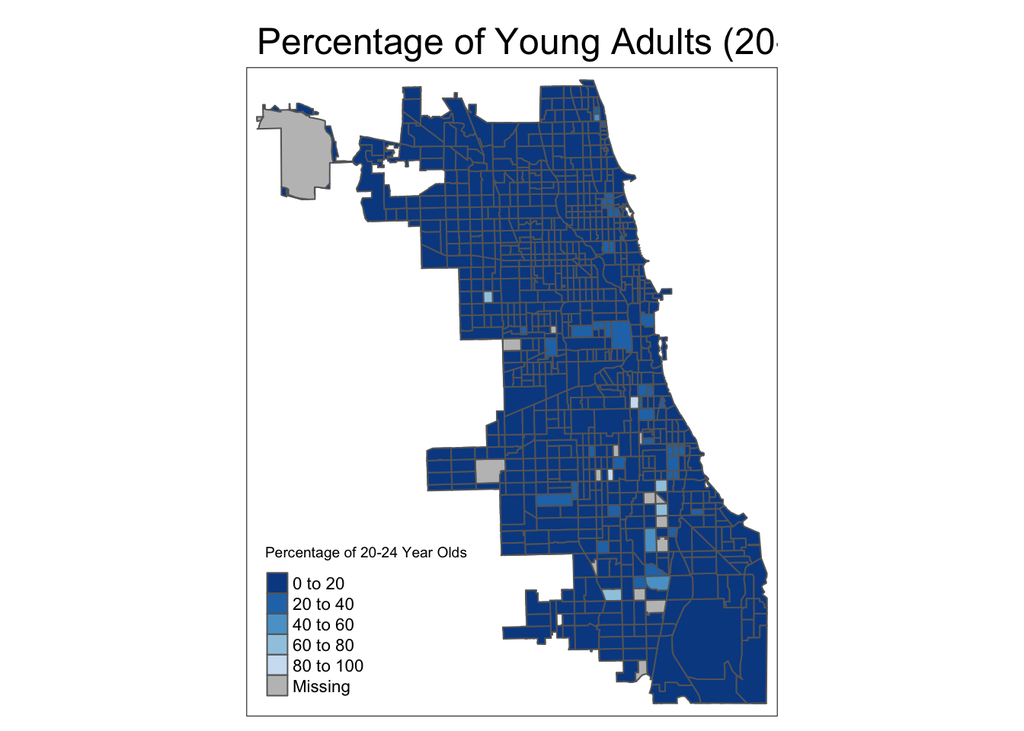

```r
# step 3
combined_data_sf <- st_as_sf(combined_data, sf_column_name = "geometry")

# selecting only necessary columns for the new dataframe
tract_level <- combined_data_sf %>%
  select(GEOID, NAME, total_population = estimate.x, male_20_24 = estimate.y, female_20_24 = estimate, percentage_20_24) %>%

  # removing empty geometries to avoid problems when mapping
  filter(!st_is_empty(geometry))



# step 4
# read in the boundary file provided
chicago_boundary <- st_read("/Users/jonathanbernard/Desktop/UIUC/Spring 2024/GGIS 224/GGIS224/Labs/Lab8/boundaries_chicago.geojson")
# making sure that CRS matches (CRS = 4326) for both datasets
tract_level <- st_transform(tract_level, crs = 4326)
chicago_boundary <- st_transform(chicago_boundary, crs = 4326)

# intersect the two spatial dataframes
chicago_tracts <- st_intersection(tract_level, chicago_boundary)
# double checking that no empty geometries after intersection to avoid problems when mapping
chicago_tracts <- chicago_tracts[!st_is_empty(chicago_tracts), , drop = FALSE]

# mapping the percentage of 20-24 year olds in each Chicago census tract in blue
tm_shape(chicago_tracts) +
  tm_polygons(col = "percentage_20_24",
              palette = "-Blues",
              title = "Percentage of 20-24 Year Olds") +
  tm_layout(main.title = "Percentage of Young Adults (20-24) in the Chicago area") +
  tm_borders(alpha = 0.5)
```

[figure not shown]

```r
# step 5
variables <- load_variables(2020, "acs5", cache = TRUE)
zcta_data <- get_acs(geography = 'zcta',
                     variables = c("B01001A_001", "B01001A_008", "B01001A_023"),
                     year = 2020,
                     geometry = TRUE) %>%
  pivot_wider(
    names_from = variable,
    values_from = estimate
  ) %>%
  mutate(
    percentage_20_24 = (`B01001A_008` + `B01001A_023`) / `B01001A_001` * 100
  ) %>%
  select(GEOID, NAME, `B01001A_001`, `B01001A_008`, `B01001A_023`, percentage_20_24, geometry)
# step 6:
chicago_boundary_zip <- st_read("/Users/jonathanbernard/Desktop/UIUC/Spring 2024/GGIS 224/GGIS224/Labs/Lab8/boundaries_chicago.geojson") %>%
  st_transform(4326)
zcta_data_wide <- st_transform(zcta_data, 4326)
intersected_data <- st_intersection(zcta_data_wide, chicago_boundary_zip)
intersected_data <- intersected_data[!st_is_empty(intersected_data), ]
tm_shape(intersected_data) +
  tm_polygons("percentage_20_24", palette="-Blues", title="Percentage of 20-24 Year Olds") +
  tm_layout(main.title="Chicago: Percentage of 20-24 Year Olds by ZIP Code",
            main.title.position="center",
            frame=FALSE)
```

Render your document by clicking on the “Knit” option in RStudio. Upload the .html file to your assignment submission!

.